# Analysis of NYPD Shooting Incident Data

Giri Kunche

5/18/2021

## Project Description

Gun violence continues to be one of the major issues in United States. Gun Violence has resulted in tens of thousands of deaths and injuries very year. I have done the analysis of shootings in New York City which is one of the largest cities in United States. The analysis is based on the data provided by NYC Open Data :https://data.cityofnewyork.us .

The data set contains breakdown of every shooting incident that occured in NYC going back to 2006 through the end of 2020. Each record represents a shooting event and includes information about the event like the location, date and time of occurrence, borough where the shooting incident occurred, precinct where the shooting incident occurred, juridiction code, location , preperator’s age group,sex and race, victim’s sex, age and race , longitude and latitude of the location.

New York City is divided into five borough’s : Booklyn, Bronx, Manhattan, Staten Island and Queens. My analysis will explore year on year shooting trend. We will examine patterns of shootings by borough’s.

## Load Libraries

Load tidyverse and lubridate libraries.

```r
library(tidyverse)
library(lubridate)
library(knitr)
```

## Downloading Data

The data is downloaded from https://data.cityofnewyork.us/api/views/833y-fsy8/rows.csv?accessType=DOWNLOAD. This data is a free public data published by New York City agencies.

```r
##Get NYC Shooting Incident Data from https://catalog.data.gov/dataset
url_in <- "https://data.cityofnewyork.us/api/views/833y-fsy8/rows.csv?accessType=DOWNLOAD"
raw_data <-read_csv(url_in)
```

## Data Analysis

There are total 19 columns and 23568 rows in the dataset. Data set consist of columns INCIDENT_KEY, OCCUR_DATE, OCCUR_TIME, BORO, PRECINCT, JURISDICTION_CODE, LOCATION_DESC, STATISTICAL_MURDER_FLAG, PERP_AGE_GROUP, PERP_SEX, PERP_RACE, VIC_AGE_GROUP, VIC_SEX, VIC_RACE, X_COORD_CD, Y_COORD_CD, Latitude, Longitude, Lon_Lat.

Remove INCIDENT_KEY, X_COORD_CD, Y_COORD_CD, Latitude, Longitude and Lon_Lat columns as they are not needed for data analysis.  
OCCUR_DATA has date of shootings and is in character format. We will convert this column to date format.

Following is the output of NYC data removing above columns.

```r
df <- raw_data %>% mutate(OCCUR_DATE=mdy(OCCUR_DATE))
nyc_data <-select(df,-INCIDENT_KEY,-X_COORD_CD,-Y_COORD_CD,-Latitude,-Longitude,-Lon_Lat)
kable(nyc_data[1:5,])
```

| OCCUR_DATE | OCCUR_TIME | BORO | PRECINCT | JURISDICTION_CODE | LOCATION_DESC | STATISTICAL_MURDER_FLAG | PERP_AGE_GROUP | PERP_SEX | PERP_RACE | VIC_AGE_GROUP | VIC_SEX | VIC_RACE |
| --- | --- | --- | --- | --- | --- | --- | --- | --- | --- | --- | --- | --- |
| 2019-08-23 | 22:10:00 | QUEENS | 103 | 0 | NA | FALSE | NA | NA | NA | 25-44 | M | BLACK |
| 2019-11-27 | 15:54:00 | BRONX | 40 | 0 | NA | FALSE | <18 | M | BLACK | 25-44 | F | BLACK |
| 2019-02-02 | 19:40:00 | MANHATTAN | 23 | 0 | NA | FALSE | 18-24 | M | WHITE HISPANIC | 18-24 | M | BLACK HISPANIC |
| 2019-10-24 | 00:52:00 | STATEN ISLAND | 121 | 0 | PVT HOUSE | TRUE | 25-44 | M | BLACK | 25-44 | F | BLACK |
| 2019-08-22 | 18:03:00 | BRONX | 46 | 0 | NA | FALSE | 25-44 | M | BLACK HISPANIC | 18-24 | M | BLACK |

## Summarizing Data

```r
group_by_boro <- nyc_data %>%group_by(BORO,OCCUR_DATE) %>%summarise(Shootings=n())
nyc_data_year<-nyc_data%>%mutate(Year=year(OCCUR_DATE),Murder=(STATISTICAL_MURDER_FLAG == TRUE)*1)%>%group_by(Year)
shootings_by_year<- nyc_data_year %>%group_by(Year) %>%summarise(Murder=sum(Murder),Shootings=n())
shootings_by_boro<-nyc_data_year %>% group_by(Year,BORO) %>% summarise(Shootings=n())
murders_by_boro<-nyc_data_year %>% group_by(Year,BORO) %>% summarise(Murder=sum(Murder))
```

## Visualization

Lets visualize the shooting and murder data by Boro’s. Below bar plot shows the number of shootings in several boroughs. Brooklyn has the highest shootings recorded followed by Bronx. Shooting and Murder trend is shown in next chart. There is decreasing trend in both shootings and murders since 2006. However, there is a spike in both in 2020.

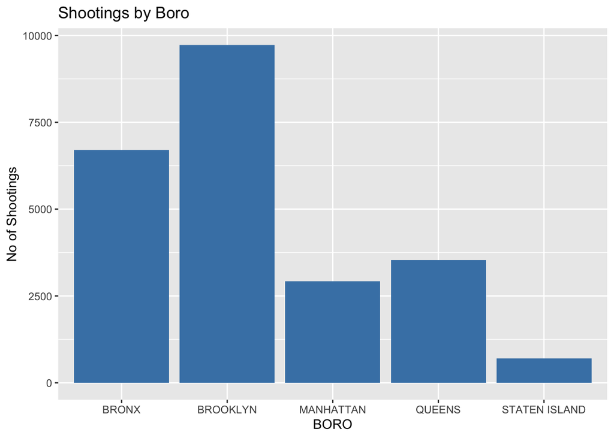

```r
group_by_boro %>% ggplot(aes(x= BORO, y = Shootings))+geom_bar(stat="identity",fill="steelblue")+theme(legend.position = "bottom")+ labs(title ="Shootings by Boro",y="No of Shootings")
```

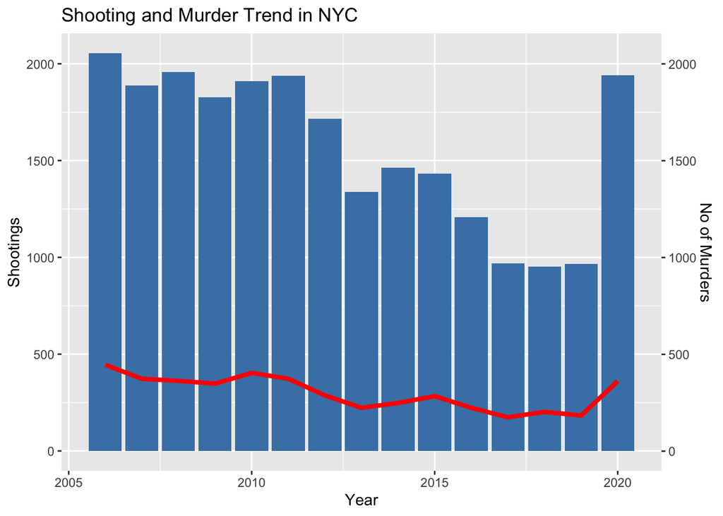

```r
ggplot(shootings_by_year,aes(x=Year)) + geom_bar(stat="identity",aes(y=Shootings),fill="steelblue") + geom_line(aes(y=Murder),size=1.5,color="red") + scale_y_continuous(sec.axis = sec_axis(~./1,name="No of Murders"))+labs(title="Shooting and Murder Trend in NYC")
```

Further drill down of trend by Boro’s shows Murder trend by Boro’s as well as comparison of Number of Shootings and Murders since 2006.

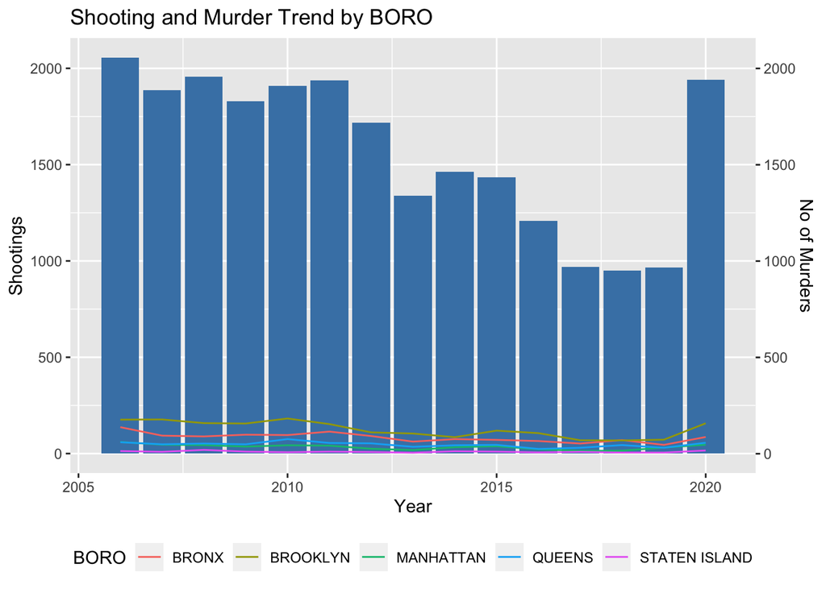

```r
ggplot(shootings_by_boro,aes(x=Year))+geom_bar(stat="identity",aes(y=Shootings),fill="steelblue") + geom_line(data=murders_by_boro,aes(x=Year,y=Murder,group=BORO,color=BORO))+scale_y_continuous(sec.axis = sec_axis(~./1,name="No of Murders"))+labs(title="Shooting and Murder Trend by BORO")+theme(legend.direction = "horizontal",legend.position = "bottom")
```

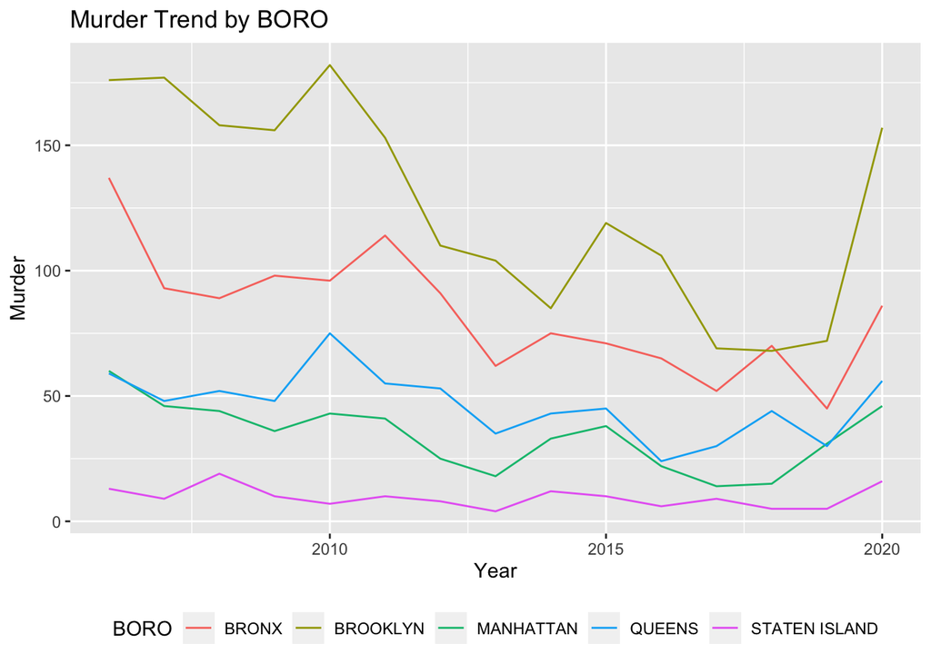

```r
ggplot(murders_by_boro,aes(x=Year)) + geom_line(aes(y=Murder,group=BORO,color=BORO))+labs(title="Murder Trend by BORO")+theme(legend.direction = "horizontal",legend.position = "bottom")
```

Below chart shows the number of shootings by Boro’s and Victim Age Group. Age group 25-44 are in high proportion compared to other age groups. Most of the victims are males.

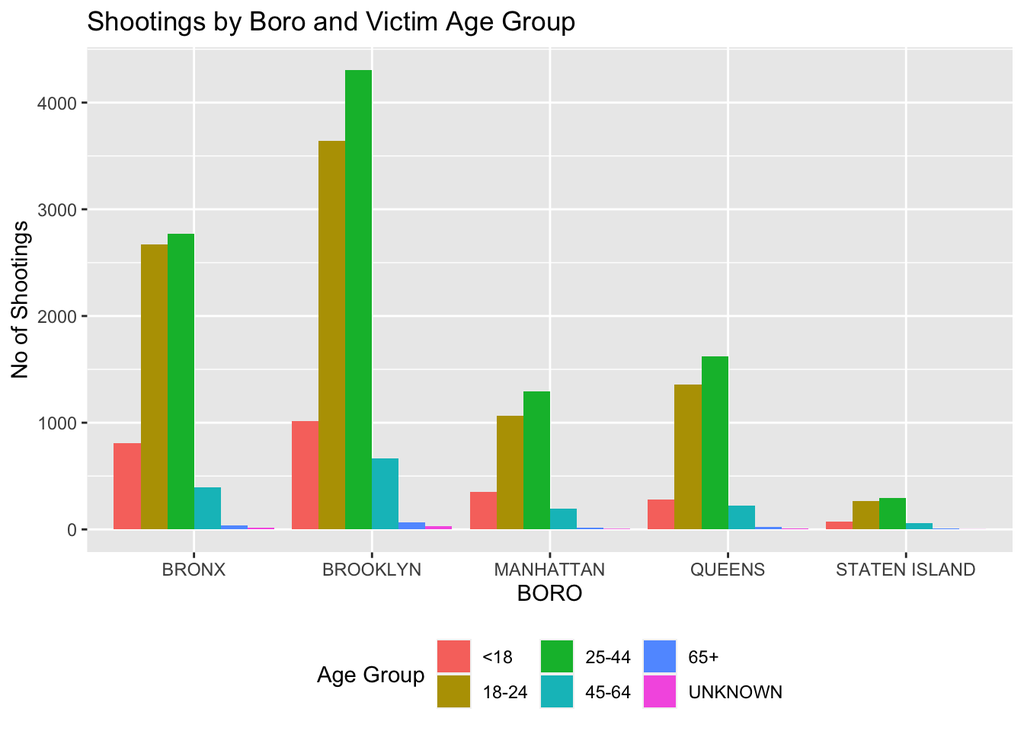

```r
ggplot(nyc_data_year,aes(x=BORO,fill=VIC_AGE_GROUP))+geom_bar(position=position_dodge())+labs(title ="Shootings by Boro and Victim Age Group",y="No of Shootings",fill="Age Group")+theme(legend.direction = "horizontal",legend.position = "bottom")
```

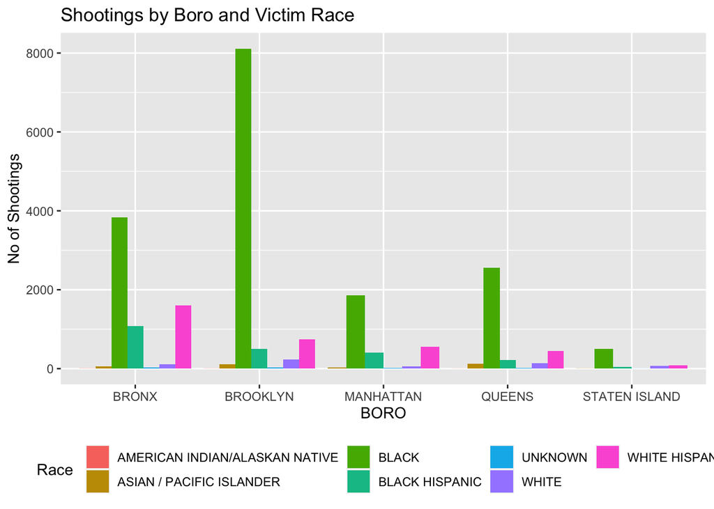

```r
ggplot(nyc_data_year,aes(x=BORO,fill=VIC_RACE))+geom_bar(position=position_dodge())+labs(title ="Shootings by Boro and Victim Race",y="No of Shootings",fill="Race ")+theme(legend.direction = "horizontal",legend.position = "bottom")
```

## Modelling

Lets consider how the number of murders are related to number of shootings. To examine this relationship, we will first summarize shooting and murder data from nyc_data_year.  
Below is the Shootings and Murders summarized by Year.

```r
shooting_murder_analysis<-nyc_data_year%>%group_by(Year)%>%summarise(Murder=sum(Murder),Shootings=n())
kable(shooting_murder_analysis)
```

| Year | Murder | Shootings |
| --- | --- | --- |
| 2006 | 445 | 2055 |
| 2007 | 373 | 1887 |
| 2008 | 362 | 1958 |
| 2009 | 348 | 1828 |
| 2010 | 403 | 1910 |
| 2011 | 373 | 1939 |
| 2012 | 287 | 1717 |
| 2013 | 223 | 1339 |
| 2014 | 248 | 1464 |
| 2015 | 283 | 1434 |
| 2016 | 223 | 1208 |
| 2017 | 174 | 969 |
| 2018 | 202 | 951 |
| 2019 | 183 | 967 |
| 2020 | 361 | 1942 |

Next step is to create a linear regressing model and find the relationship between Murders and Shootings. Following is the output of linear regression model.

```r
mod<-lm(shooting_murder_analysis$Murder ~ shooting_murder_analysis$Shootings, data=shooting_murder_analysis)
summary(mod)
```

```
##
## Call:
## lm(formula = shooting_murder_analysis$Murder ~ shooting_murder_analysis$Shootings,
##     data = shooting_murder_analysis)
##
## Residuals:
##     Min      1Q  Median      3Q     Max
## -42.364 -16.069  -1.058  10.493  45.708
##
## Coefficients:
##                                     Estimate Std. Error t value Pr(>|t|)
## (Intercept)                        -25.86201   27.32092  -0.947    0.361
## shooting_murder_analysis$Shootings   0.20689    0.01688  12.260 1.62e-08 ***
## ---
## Signif. codes:  0 '***' 0.001 '**' 0.01 '*' 0.05 '.' 0.1 ' ' 1
##
## Residual standard error: 25.52 on 13 degrees of freedom
## Multiple R-squared:  0.9204, Adjusted R-squared:  0.9143
## F-statistic: 150.3 on 1 and 13 DF,  p-value: 1.616e-08
```

We will add the murder prediction (Murder_Predicted) from linear model to a new data set murder_pred.

```r
murder_pred<-shooting_murder_analysis%>% mutate(Murder_Predicted=predict(mod))
kable(murder_pred)
```

| Year | Murder | Shootings | Murder_Predicted |
| --- | --- | --- | --- |
| 2006 | 445 | 2055 | 399.2923 |
| 2007 | 373 | 1887 | 364.5351 |
| 2008 | 362 | 1958 | 379.2242 |
| 2009 | 348 | 1828 | 352.3288 |
| 2010 | 403 | 1910 | 369.2936 |
| 2011 | 373 | 1939 | 375.2933 |
| 2012 | 287 | 1717 | 329.3642 |
| 2013 | 223 | 1339 | 251.1607 |
| 2014 | 248 | 1464 | 277.0216 |
| 2015 | 283 | 1434 | 270.8150 |
| 2016 | 223 | 1208 | 224.0584 |
| 2017 | 174 | 969 | 174.6122 |
| 2018 | 202 | 951 | 170.8882 |
| 2019 | 183 | 967 | 174.1984 |
| 2020 | 361 | 1942 | 375.9140 |

We will now plot between the actual murders vs predicted murders and check how will the model fits. The blue dots are the actual murders and the red dots are the predicted murders.  
The model does well when there is cluster of data nearby. Overall the model prediction is closer to the actual values.

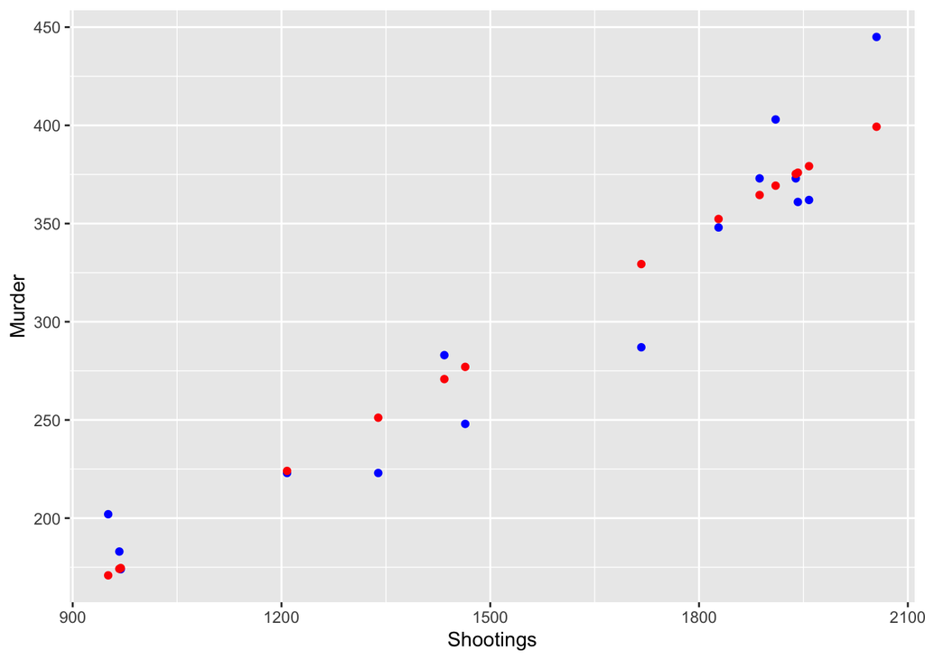

```r
murder_pred %>% ggplot() + geom_point(aes(x=Shootings, y = Murder),color="blue") + geom_point(aes(x=Shootings,y=Murder_Predicted),color="red")
```

## Bias

Only Number of Shootings and Murders are considered to predict the murders. We have left out Perperator Race, Sex, Age as well as location of the shooting. These variables may have influence on the murder or shootings.